# Time Series Analysis of Airline Passanger Travel

Aishwarya Pant (pant.26)

2023-04-23

# Introduction to Dataset

The airline sector is an essential to linking people and products everywhere. In the project the goal is to look at important insights into patterns and changes over time that will help comprehend the trends in passenger traffic.

The data set used in the project provides the number of domestic and international passengers. The dataset was obtained from the United State Bureau of Transportation. This dataset provides information about monthly Passengers who travel by air from January 2003 to January 2023. For the purpose of this project I will only consider International air travel data from January 2003 to December 2022.

# Explanatory Analysis

## Visualize the Data: Begin by plotting the time series to get a sense of the overall pattern.

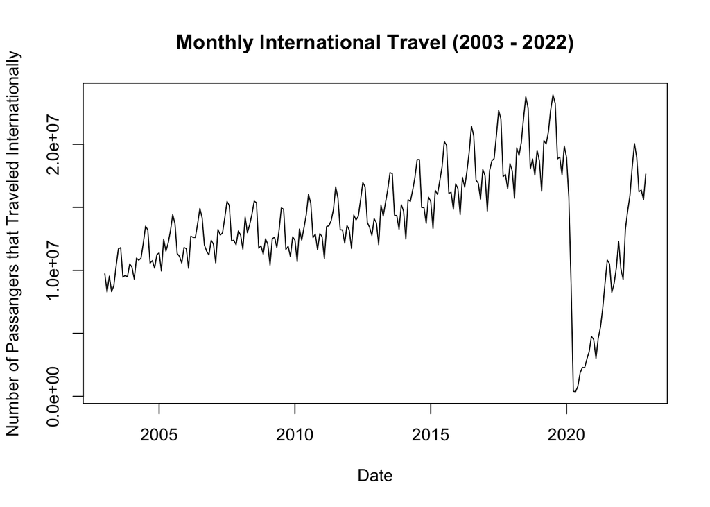

```r
library(readxl)
library(ggplot2)
library(forecast)
library(astsa)
AirTravel_Passanger <- read_excel("~/Desktop/AirTravel_Passanger.xlsx")

international <- AirTravel_Passanger$International
internationalTSO <- ts(international)

internationalTS <- ts(international, start = c(2003, 1), end = c(2022, 12), freq = 12)
internationalTime <- time(internationalTS)

internationalT <- c(internationalTime)

# Figure 1
plot(internationalTS, xlab = "Date", ylab = "Number of Passangers that Traveled Internationally", main = "Monthly International Travel (2003 - 2022)", type = "l")
```

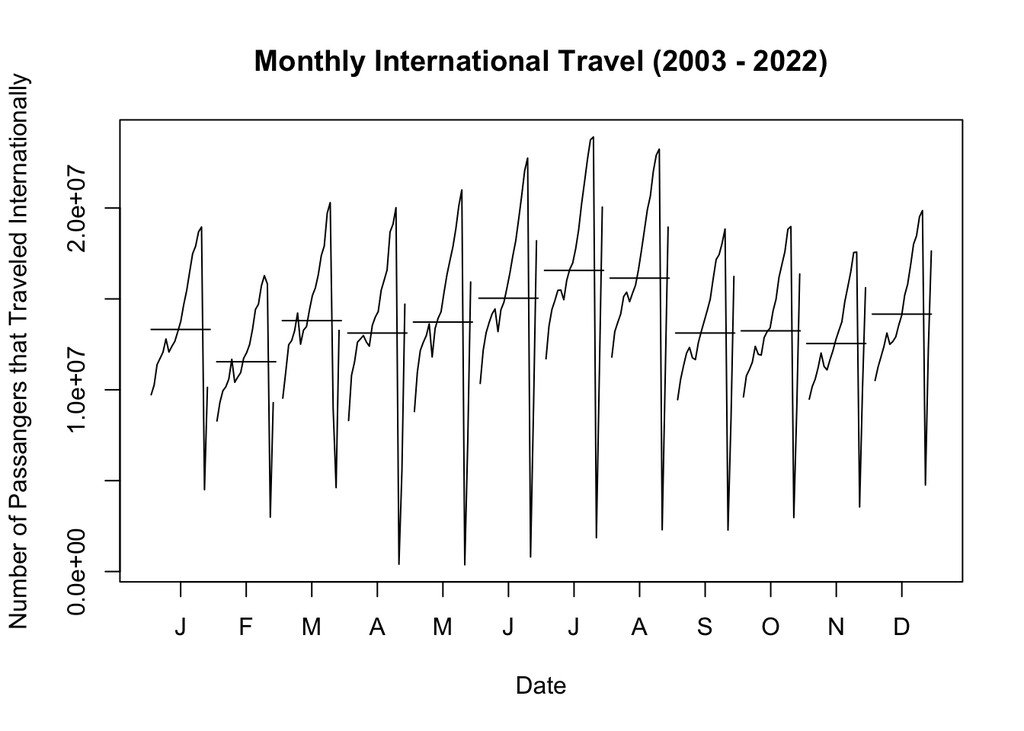

```r
# Figure 2
monthplot(internationalTS,xlab = "Date", ylab = "Number of Passangers that Traveled Internationally", main = "Monthly International Travel (2003 - 2022)" )
```

## Examine the autocorrelation function (ACF) and partial autocorrelation function (PACF): This will provide insight into the correlation structure of the time series and can help identify potential non-stationarity features.

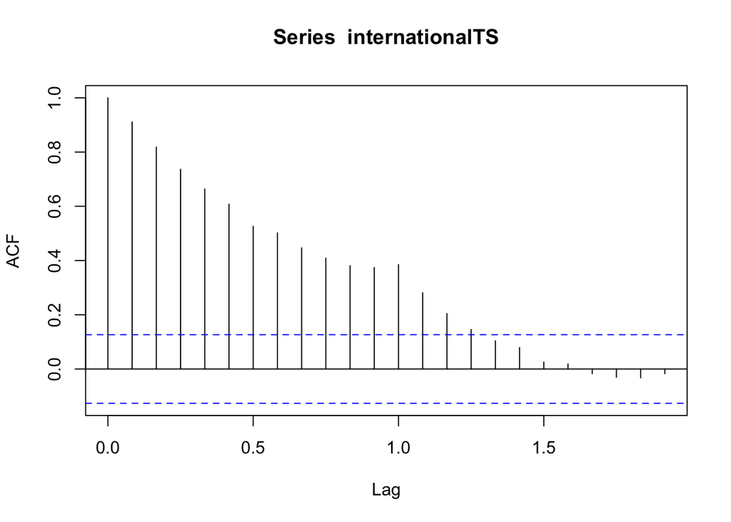

```r
# Figure 3
acf(internationalTS)
```

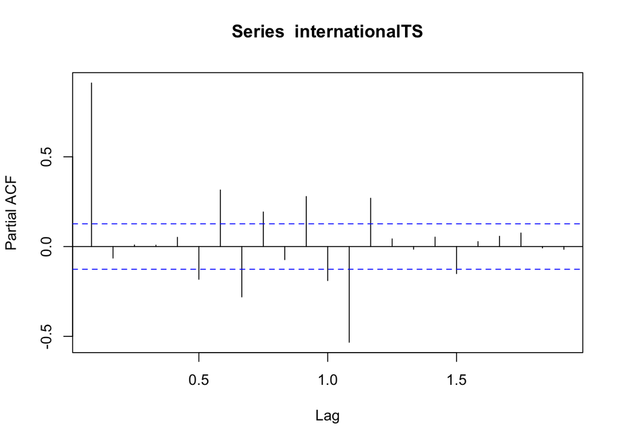

```r
# Figure 4
pacf(internationalTS)
```

The autocorrelation function plot shown in Figure 3 shows the correlation between value changes over time. As seen in Figure 3 it is a non-stationary time series because the correlation between the values decreases over time. This indicates some non-random behavior/ trend.

In the PACF graph shown in Figure 4 there are significant spikes at multiple lags. This helps us to identify that there are non-stationary features in the time series data set.

# First Analysis of Data

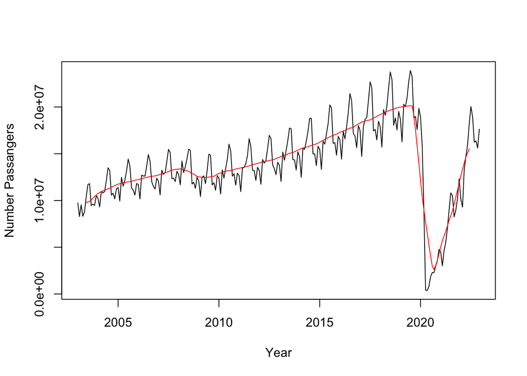

```r
# Calculate a 12-month moving average smoother (to capture seasonality)
ma_smoother <- filter(internationalTS, rep(1/12, 12), sides = 2)
plot(internationalTS, xlab = "Year", ylab = "Number Passangers")
lines(ma_smoother, col = "red")
```

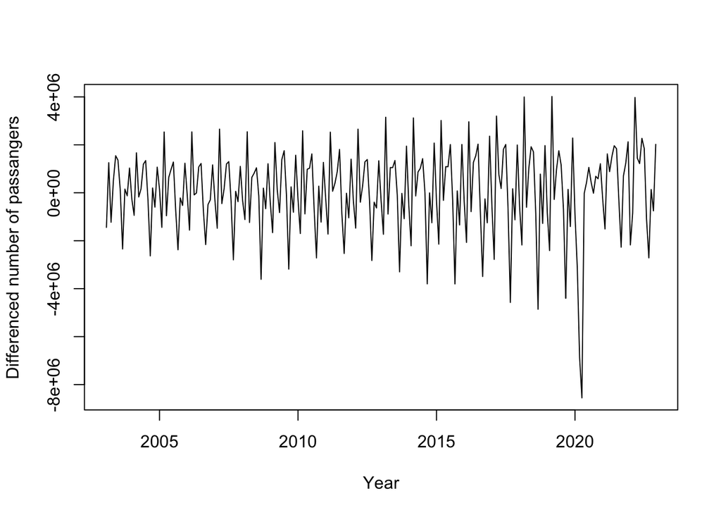

```r
# Calculate the first difference of time series
diff_data <- diff(internationalTS)

# Plot the differenced data
plot(diff_data, xlab = "Year", ylab = "Differenced number of passangers" )
```

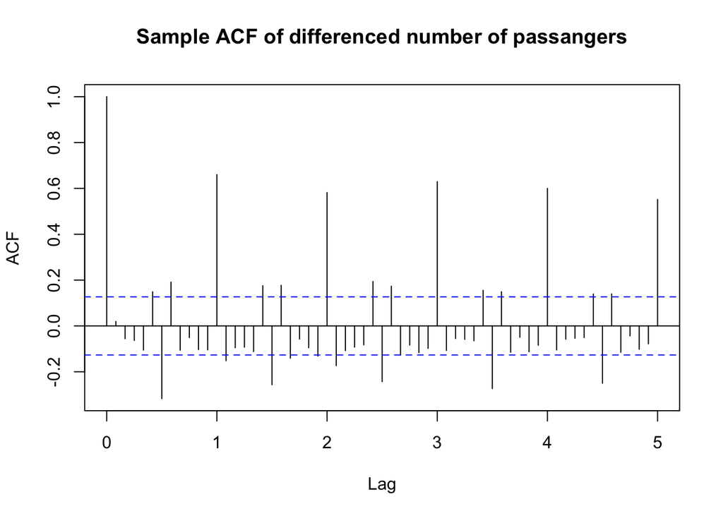

```r
# plot the sample ACF
acf(diff_data, lag.max = 60, main = "Sample ACF of differenced number of passangers")
```

In order to detrend and deseasonalize the data I can begin by using the multiplicative ARIMA approch.

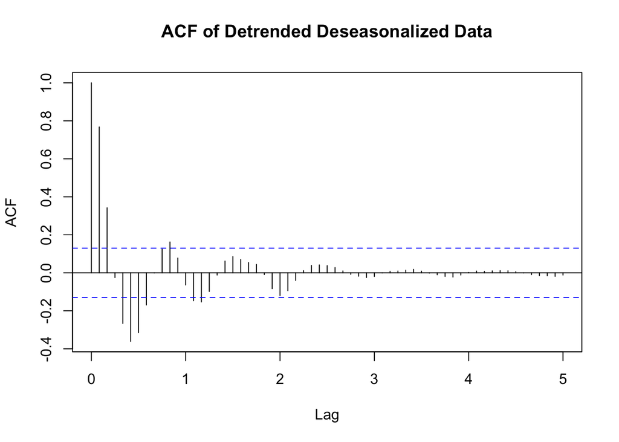

```r
decomp <- decompose(internationalTS, type = "multiplicative")

# Extract seasonal and trend components from decomposed data
seasonal <- decomp$seasonal
trend <- decomp$trend

# Remove seasonal and trend components from original data
detrended_deseasonalized_data <- internationalTS / (trend * seasonal)
detrended_deseasonalized_data <- na.omit(detrended_deseasonalized_data)

# Plot the ACF and PACF of the detrended, deseasonalized data
acf(detrended_deseasonalized_data, lag.max = 60, main = "ACF of Detrended Deseasonalized Data")
```

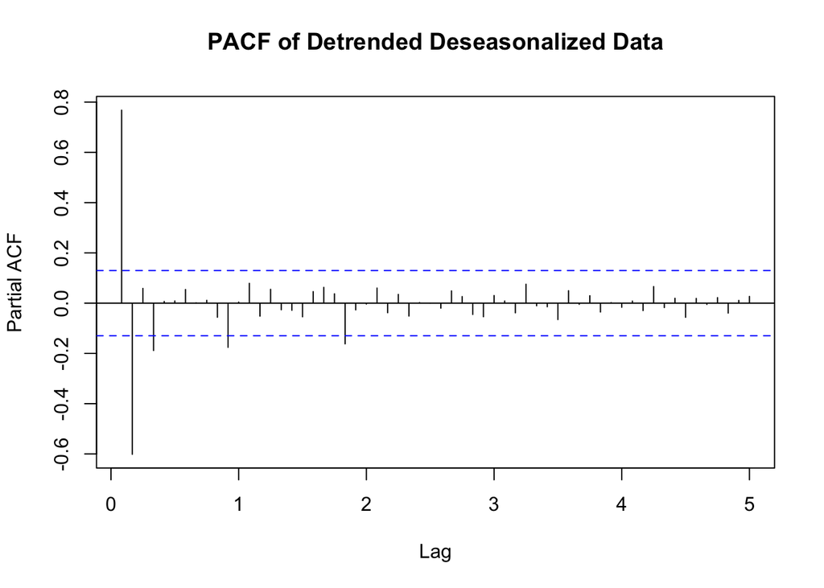

```r
pacf(detrended_deseasonalized_data, lag.max = 60, main = "PACF of Detrended Deseasonalized Data")
```

Based on the ACF and PACF plots, it appears that an AR(1), MA(1), or AR(1)MA(1) model might be appropriate. We can fit these models and compare them using information criteria such as AIC and BIC.

```r
# Fit an AR(1) model
ar1_model <- arima(detrended_deseasonalized_data, order = c(1, 0, 0))
summary(ar1_model)
```

```
##
## Call:
## arima(x = detrended_deseasonalized_data, order = c(1, 0, 0))
##
## Coefficients:
##         ar1  intercept
##       0.767     0.9915
## s.e.  0.042     0.0253
##
## sigma^2 estimated as 0.008161:  log likelihood = 224.2,  aic = -442.4
##
## Training set error measures:
##                         ME       RMSE        MAE       MPE    MAPE      MASE
## Training set -0.0001079387 0.09033615 0.03886717 -9.567158 13.2075 0.9273433
##                   ACF1
## Training set 0.4662401
```

```r
# Fit an MA(1) model
ma1_model <- arima(detrended_deseasonalized_data, order = c(0, 0, 1))
summary(ma1_model)
```

```
##
## Call:
## arima(x = detrended_deseasonalized_data, order = c(0, 0, 1))
##
## Coefficients:
##          ma1  intercept
##       0.8653     0.9899
## s.e.  0.0290     0.0110
##
## sigma^2 estimated as 0.007912:  log likelihood = 227.48,  aic = -448.97
##
## Training set error measures:
##                        ME       RMSE        MAE       MPE     MAPE     MASE
## Training set 8.053137e-06 0.08894818 0.04630828 -10.07611 14.29662 1.104883
##                   ACF1
## Training set 0.4508265
```

```r
# Fit AR(1)MA(1) model
ar1ma1_model <- arima(detrended_deseasonalized_data, order = c(1, 0, 1))
summary(ar1ma1_model)
```

```
##
## Call:
## arima(x = detrended_deseasonalized_data, order = c(1, 0, 1))
##
## Coefficients:
##          ar1     ma1  intercept
##       0.6133  0.6574     0.9909
## s.e.  0.0563  0.0492     0.0209
##
## sigma^2 estimated as 0.005539:  log likelihood = 267.96,  aic = -527.92
##
## Training set error measures:
##                         ME       RMSE        MAE       MPE     MAPE      MASE
## Training set -2.867382e-05 0.07442417 0.04029868 -5.187127 9.088528 0.9614979
##                    ACF1
## Training set 0.09989536
```

```r
# Compare models using AIC and BIC
AIC(ar1_model, ma1_model, ar1ma1_model)
```

```
##              df       AIC
## ar1_model     3 -442.3997
## ma1_model     3 -448.9666
## ar1ma1_model  4 -527.9250
```

```r
BIC(ar1_model, ma1_model, ar1ma1_model)
```

```
##              df       BIC
## ar1_model     3 -432.1116
## ma1_model     3 -438.6786
## ar1ma1_model  4 -514.2076
```

After fitting several models and comparing their AIC and BIC values, ARIMA(1,0,1) model is the final fitted model for the international air passenger data set. The model can be written as:

$y_t = 0.9909 + 0.6133y_{t-1} + w_t + 0.6574 w_{t-1}$

$y_t$ represents the de-trended and de-seasonalized time series, w_t is the error term at time t, and w_{t-1} is the error term at time t-1.

I chose this model based on its lower AIC and BIC values compared to the other models.

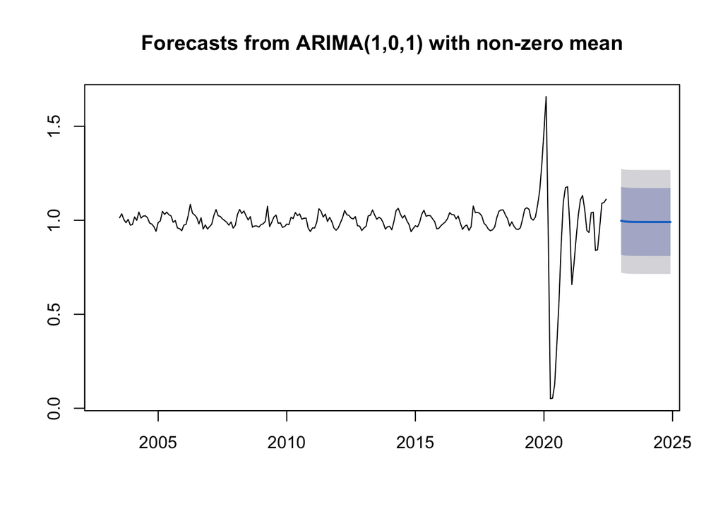

```r
# Add back the seasonal and trend components
seasonal_trend <- seasonal * trend
originalTS <- internationalTS / seasonal_trend

# Fit the ARIMA(1,0,1) model
ar1ma1_model <- arima(originalTS, order = c(1, 0, 1))

# Generate forecasts and prediction intervals for the next 24 months
forecast_ar1ma1 <- forecast(ar1ma1_model, h = 24)
plot(forecast_ar1ma1)
```

The resulting plot shows the forecasted values (in blue) along with 80% and 95% prediction intervals (in shaded areas). These prediction intervals capture the uncertainty in the forecasts. Overall, the ARIMA(1,0,1) model seems to provide a good fit to the data.

The final ARIMA(1,0,1) model suggests that the international air passenger data has a significant autoregressive component and a significant moving average component. Specifically, the model suggests that there is a positive relationship between the current observation and the previous observation, and that the error term at the current time point is positively related to the error term at the previous time point.

# Second Analysis of Data

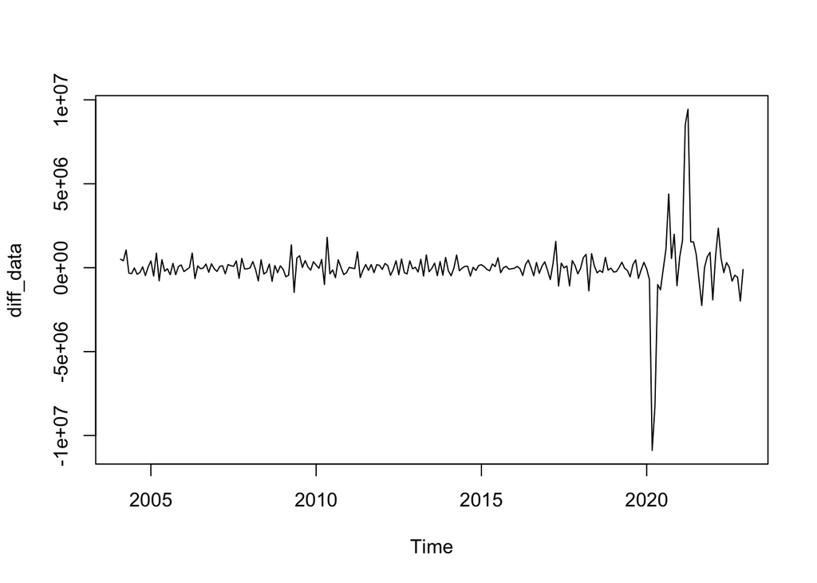

```r
diff_data <- diff(diff_data, lag = 12, differences = 1)
plot(diff_data)
```

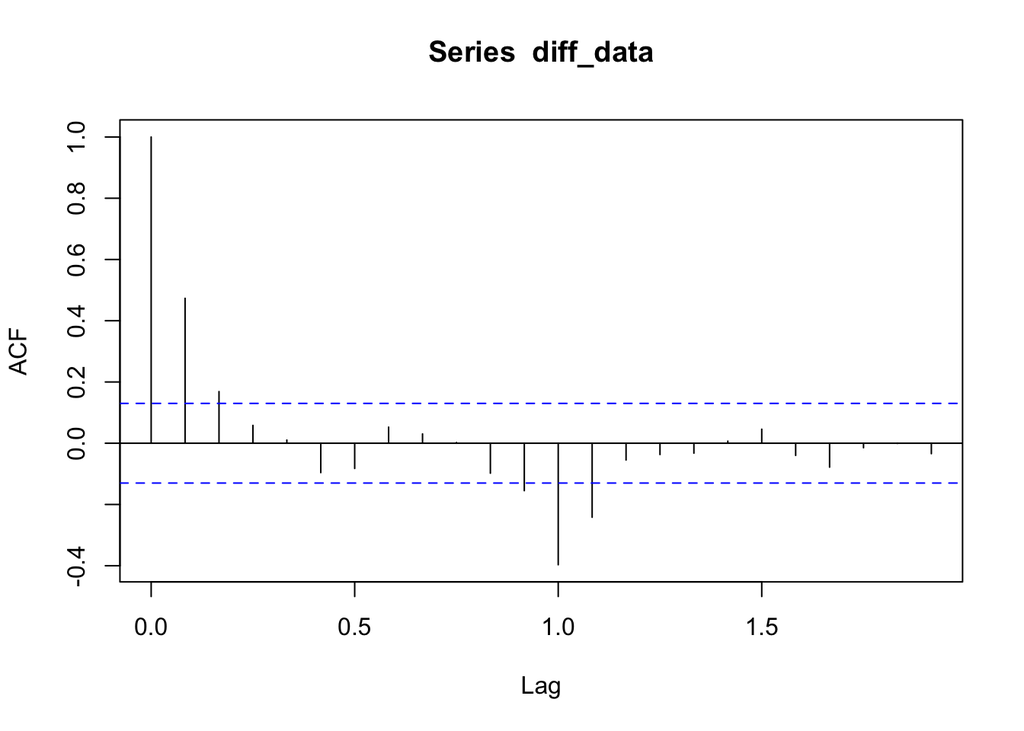

```r
acf <- acf(diff_data)
```

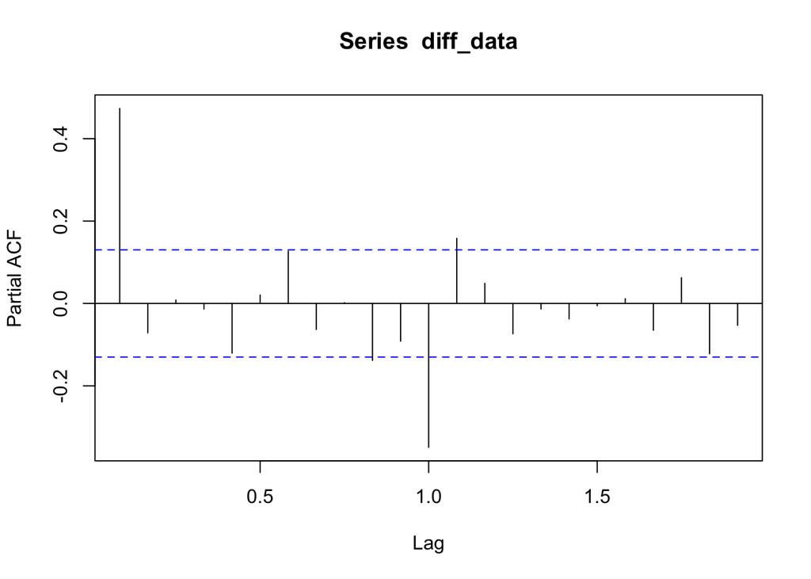

```r
pacf <- pacf(diff_data)
```

```r
summary(acf)
```

```
##        Length Class  Mode
## acf    24     -none- numeric
## type    1     -none- character
## n.used  1     -none- numeric
## lag    24     -none- numeric
## series  1     -none- character
## snames  0     -none- NULL
```

```r
summary(pacf)
```

```
##        Length Class  Mode
## acf    23     -none- numeric
## type    1     -none- character
## n.used  1     -none- numeric
## lag    23     -none- numeric
## series  1     -none- character
## snames  0     -none- NULL
```